# Bias introduced by over/underdispersion

Michal Burdukiewicz

17.10.2015

# Distribution density definition

$P\{X = K\} = \begin{cases} (1 - p) + p \exp^{-\lambda},\text{if } k = 0\\ p \frac{\lambda^k \exp^{-\lambda}}{k!},\text{if } k = 1, 2, \ldots \end{cases}$ as in Wang et al. (2012).

If $p = 1$, than we have normal Poisson distribution.

Mean: $\mu = p \lambda$

Variance: $\sigma^2 = p \lambda + p(1 - p)\lambda^2$

When $p > 1$, the distribution is underdispersed under condition that: $p \leq \frac{1}{1 - \exp{(- \lambda)}}$

When $p < 1$, the distribution is overdispersed.

# Distribution density

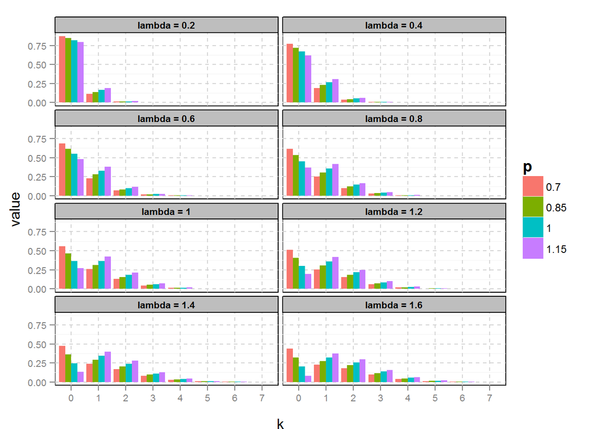

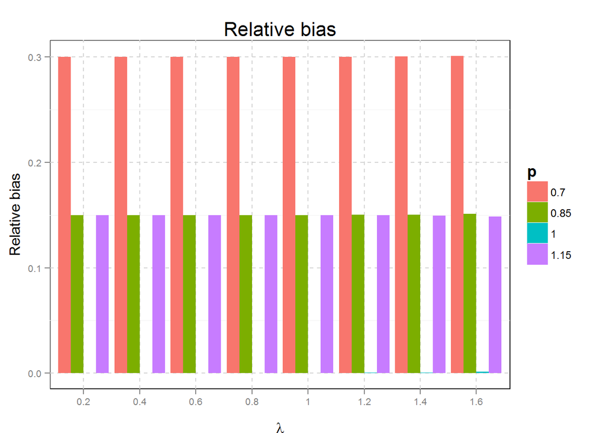

The relative bias ($\frac{\mu - \lambda}{\lambda}$) does not depend on the $\lambda$, but only on $p$.

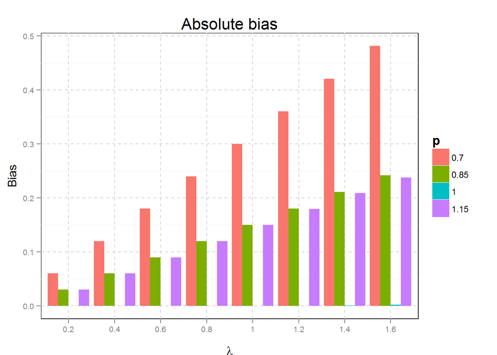

Absolute bias is proportional to $\lambda$ and still depends on $p$.

# Conclusions

Taking into account over- and underdispersion always reduces the bias of estimated mean number of counted object per cell. Only in case of many counted objects per cell, the correction for over- and underdispersion will be visible.

It’s not like we did a breakthough analysis, because all that is visible from the definition of mean in this distribution. We just confirmed that: $\mu = p \lambda$

But it also means that influence on the variance would be much higher. If $\sigma^2 = p \lambda + p(1 - p)\lambda^2$ than it’s easy to calculcate the bias of estimated variance.

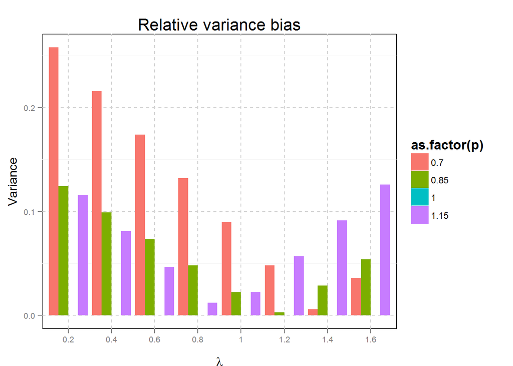

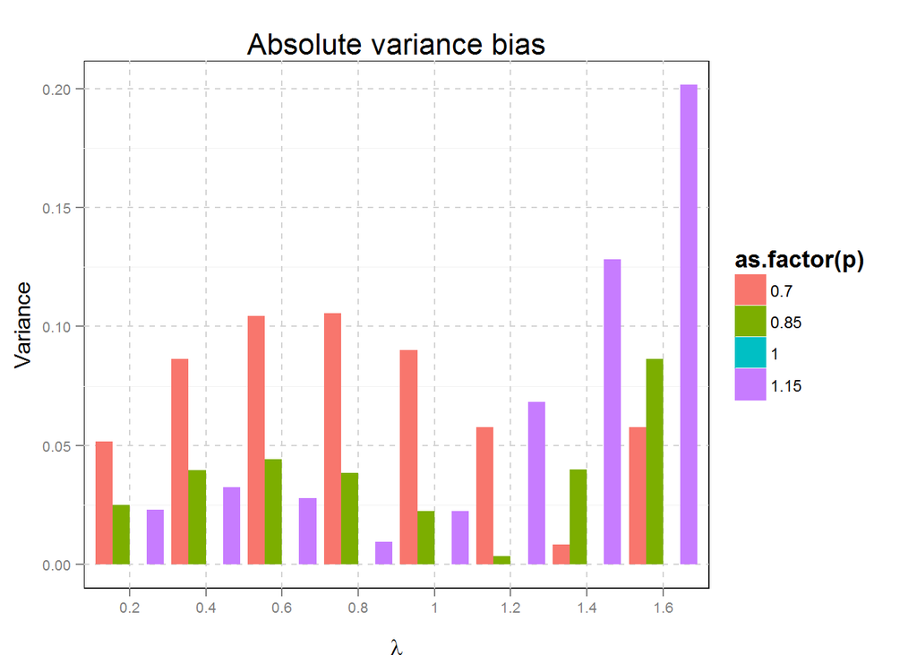

References

Wang, Hongyue, Changyong Feng, Xinming Tu, and Jeanne Kowalski. 2012. “A Comparison of Two Test Statistics for Poisson Overdispersion/Underdispersion.” *Applied Mathematics* 03 (07): 795–99. doi:10.4236/am.2012.37118.